# HMCL: data overview and exploratory analysis

Michael Tran

2026-10-30

The Human Myeloma Cell Line (HMCL) screen measures drug sensitivity across 43 curated myeloma cell lines and 1,912 compounds. This walkthrough introduces the response and mutation data, examines dose-response behavior, compares fitted curves with the published analysis, and explores sensitivity patterns and a TP53–Nutlin-3 example. The original study screened 47 lines; four were excluded by its plate-quality criteria. See the [source study](https://www.nature.com/articles/s41597-025-04989-8) for acquisition and assay details.

## Getting started

Read the serialized PharmacoSet with PharmacoGx. Response records use identifiers from `sampleInfo()` and `treatmentInfo()`; join labels through these tables instead of assuming a display name is the stored key. Keep dose, plate and technical-context fields when selecting observations.

```r
library(PharmacoGx)
library(MultiAssayExperiment)
library(data.table)
pset <- readRDS("HMCL_PSet.rds")
samples <- sampleInfo(pset)
drugs <- treatmentInfo(pset)
response <- treatmentResponse(pset)
raw <- response[["raw"]]
profiles <- response[["profiles"]]
omics <- molecularProfilesSlot(pset)
```

## Contents and identifiers

The counts distinguish physical observations from fitted or aggregated profiles. Molecular coverage varies across assays; analyses should intersect sample IDs explicitly.

| dataset | samples | source_treatments | physical_observations |
| --- | --- | --- | --- |
| Human Myeloma Cell Line | 43 | 1912 | 904376 |

| assay | rows |
| --- | --- |
| raw | 904376 |
| profiles | 82216 |
| published_profiles | 82216 |

| sampleid | sample_name | tissueid | Cellosaurus.Accession |
| --- | --- | --- | --- |
| EJM_DSMZ | EJM_DSMZ | haematopoietic_and_lymphoid | CVCL_2030 |
| MOLP8_DSMZ | MOLP8_DSMZ | haematopoietic_and_lymphoid | CVCL_2124 |
| XG1_PLB | XG1_PLB | haematopoietic_and_lymphoid | CVCL_4797 |
| UTMC2_PLB | UTMC2_PLB | haematopoietic_and_lymphoid | CVCL_4802 |
| KMS34_JCRB | KMS34_JCRB | haematopoietic_and_lymphoid | CVCL_2996 |

| treatmentid | treatment_name | PubChem.CID |
| --- | --- | --- |
| NCGC00263219-01 | Elacridar | 119373 |
| NCGC00274062-01 | Zosuquidar | NA |
| NCGC00346448-01 | Tariquidar | 148201 |
| NCGC00346894-01 | Valspodar | 5281884 |
| NCGC00159456-06 | Imatinib | 5291 |

### Select a treatment and join readable labels

This example selects an observed treatment ID and adds its label without merging distinct source compounds. Replace `selected_id` with an ID from the treatment table for a specific question.

```r
selected_id <- raw$treatment1id[[1]]
example <- raw[treatment1id == selected_id,
  .(sampleid, treatment1id, treatment1dose, dose_unit, viability)][1:5]
example <- merge(example,
  as.data.table(samples)[, .(sampleid, sample_name)], by="sampleid", all.x=TRUE)
example <- merge(example,
  as.data.table(drugs)[, .(treatment1id=treatmentid, treatment_name)],
  by="treatment1id", all.x=TRUE)
knitr::kable(example)
```

| treatment1id | sampleid | treatment1dose | dose_unit | viability | sample_name | treatment_name |
| --- | --- | --- | --- | --- | --- | --- |
| NCGC00013226-15 | AMO1_DSMZ | 0 | M | 0.8407910 | AMO1_DSMZ | Trifluoperazine |
| NCGC00013226-15 | ARD_JJKsccE7 | 0 | M | 0.7659141 | ARD_JJKsccE7 | Trifluoperazine |
| NCGC00013226-15 | ARP1_JJKsccF8 | 0 | M | 0.7914741 | ARP1_JJKsccF8 | Trifluoperazine |
| NCGC00013226-15 | Delta47_JCRB | 0 | M | 0.8363589 | Delta47_JCRB | Trifluoperazine |
| NCGC00013226-15 | EJM_DSMZ | 0 | M | 0.7762848 | EJM_DSMZ | Trifluoperazine |

### Align a molecular assay with response samples

Use the experiment’s feature metadata to interpret its rows and its column metadata to interpret samples. Match by identifiers; row or column position is not a biological mapping.

```r
se <- experiments(molecularProfilesSlot(pset))[["mutation.exome"]]
shared_samples <- intersect(samples$sampleid, colnames(se))
values <- SummarizedExperiment::assay(se)
knitr::kable(data.frame(assay="mutation.exome", features=nrow(values),
  shared_response_samples=length(shared_samples)))
```

| assay | features | shared_response_samples |
| --- | --- | --- |
| mutation.exome | 6178 | 42 |

```r
knitr::kable(values[seq_len(min(4,nrow(values))), head(shared_samples,4), drop=FALSE])
```

|  | EJM_DSMZ | MOLP8_DSMZ | XG1_PLB | UTMC2_PLB |
| --- | --- | --- | --- | --- |
| ENSG00000000419 | 0 | 0 | 0 | 0 |
| ENSG00000001084 | 0 | 0 | 0 | 0 |
| ENSG00000001617 | 0 | 0 | 0 | 0 |
| ENSG00000001626 | 0 | 0 | 0 | 0 |

## What was measured and retained

The public study measured 48-hour CellTiter-Glo responses for 1,912 compounds in 47 myeloma lines. Its source pipeline excluded four lines with plate-quality problems; the curated normalized screen contains 43. Each cell–compound curve is a **single replicate** with 11 doses. Replicate concordance cannot be estimated from this single-replicate design.

The PSet imports the publication’s background-adjusted viability, divides percent by 100, and fits the current PharmacoGx model after truncating fitting responses to [0,1]. Original responses remain intact. These checks do not independently reproduce the publication’s plate normalization.

| wells | doses | N |
| --- | --- | --- |
| 11 | 11 | 82216 |

| curves | N |
| --- | --- |
| 1 | 82216 |

| observations | samples | compounds | curves | below_zero | above_one | missing |
| --- | --- | --- | --- | --- | --- | --- |
| 904376 | 43 | 1912 | 82216 | 0 | 0 | 0 |

| metric | rows | finite | missing | median | p05 | p95 |
| --- | --- | --- | --- | --- | --- | --- |
| AAC | 82216 | 82216 | 0 | 0.3120 | 0.1814 | 0.5847 |
| Rsquare | 82216 | 82216 | 0 | 0.7678 | 0.1786 | 0.9847 |

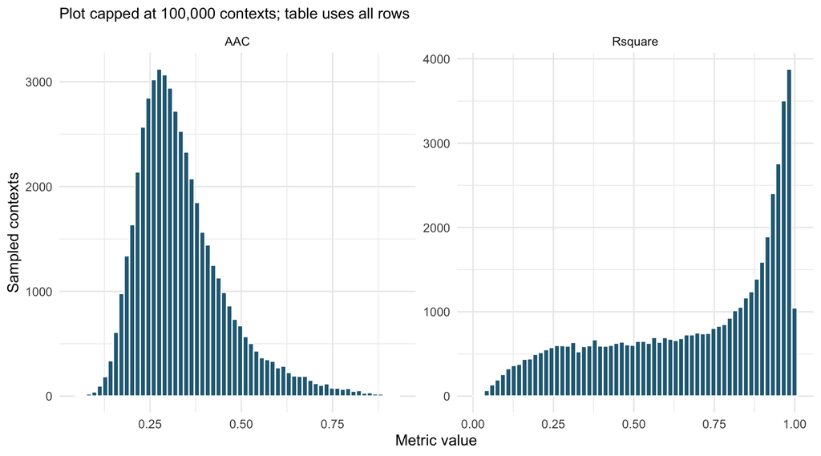

| sampleid | curves | median_AAC | median_R2 | low_R2 |
| --- | --- | --- | --- | --- |
| KMS28PE_JCRB | 1912 | 0.2427 | 0.8419 | 354 |
| KMS12BM_JCRB | 1912 | 0.2569 | 0.8103 | 402 |
| NCIH929_DSMZ | 1912 | 0.2641 | 0.9002 | 335 |
| RPMI8226_ATCC | 1912 | 0.2644 | 0.8048 | 427 |
| OPM2_DSMZ | 1912 | 0.2650 | 0.7378 | 555 |
| FR4_PLB | 1912 | 0.2655 | 0.7543 | 585 |
| H1112_PLB | 1912 | 0.2665 | 0.8528 | 386 |
| XG1_PLB | 1912 | 0.2698 | 0.8831 | 362 |
| JIM3_ECACC | 1912 | 0.2706 | 0.8674 | 371 |
| MM1R_ATCC | 1912 | 0.2719 | 0.8295 | 442 |

A successful optimizer is not a quality guarantee. Low R² on a flat response can reflect little biological signal; on a strongly changing response it can identify a poor fit. AAC summarizes response across each compound’s tested log-dose interval, so it is not a potency measurement at one common concentration.

## Published AC50 versus recomputed half-effect concentration

The [publication](https://www.nature.com/articles/s41597-025-04989-8) uses `drc::LL.4`. Its **AC50 is the fitted concentration halfway between the two asymptotes**, so the matching PharmacoGx parameter is **EC50**, not absolute 50%-viability IC50. Both are compared in log10 molar units, matched one-to-one by cell, compound and plate. No significance or fit-quality filter is applied to the primary comparison; a separately reported subset requires both estimates to fall inside the measured dose interval.

The [upstream fitting script](https://github.com/khughitt/hmcl-drug-screen-pipeline/blob/a4c5e200bfb728df209b30e118bb0f496d362b98/scripts/fit_dose_response_curves.R) fits the provided molar concentrations directly, but computes `lac50 = log10(ac50 / 1e6)`. We retain that field unchanged and report its six-log offset; it is **not** used as log10(M). Model constraints, optimizer choices and response clipping differ. Correlation alone therefore cannot establish reproduction or agreement.

| field | stored_type | parse_failures | source_values_verified |
| --- | --- | --- | --- |
| published_profiles.ac50 | character | 0 | 82216 |

| source_nonpositive | source_missing | source_positive_outside_doses | recomputed_outside_doses | both_in_range | median_lac50_offset |
| --- | --- | --- | --- | --- | --- |
| 0 | 2024 | 15761 | 14082 | 56362 | -6 |

| comparison | contexts | paired | reference_only | recomputed_only | neither | Pearson | Spearman | mean_bias | median_bias | MAE | RMSE | p95_abs_error | descriptive_lower | descriptive_upper |
| --- | --- | --- | --- | --- | --- | --- | --- | --- | --- | --- | --- | --- | --- | --- |
| All positive finite AC50 / EC50 | 82216 | 80192 | 0 | 2024 | 0 | 0.2248 | 0.7562 | -0.1528 | 0 | 0.6816 | 4.0753 | 2.7091 | -8.1349 | 7.8292 |
| Both inside measured dose interval | 56362 | 56362 | 0 | 0 | 0 | 0.8249 | 0.8461 | 0.0699 | 0 | 0.2495 | 0.6741 | 1.7949 | -1.2442 | 1.3841 |

| contexts | finite_pairs | within_twofold | within_tenfold |
| --- | --- | --- | --- |
| 82216 | 80192 | 54429 | 67592 |

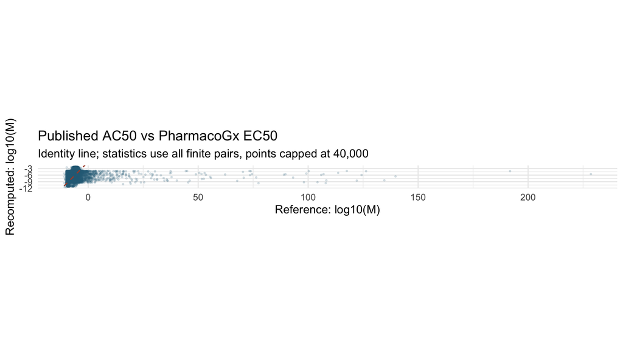

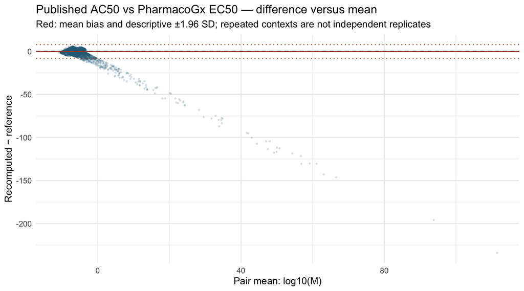

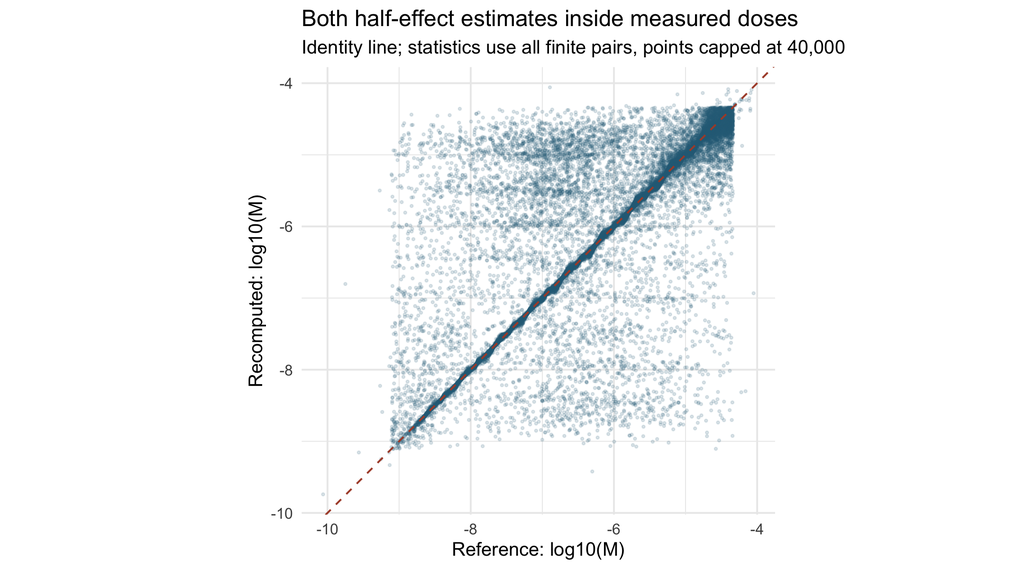

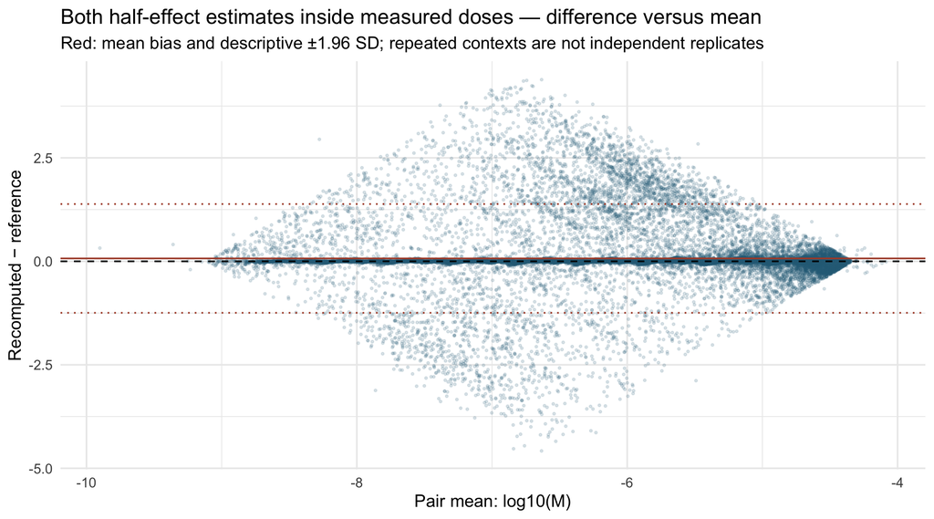

| sampleid | treatment_name | treatment1id | plateid | ac50 | EC50 | delta_log_M | min_M | max_M | Rsquare | lower_limit | upper_limit | slope |
| --- | --- | --- | --- | --- | --- | --- | --- | --- | --- | --- | --- | --- |
| MOLP8_DSMZ | Refametinib | NCGC00188380-01 | T5553462 | 9.674237e+272 | 0e+00 | -280.8110 | 0 | 0 | 0.1712 | -184.2836 | 1290.1284 | -0.0024 |
| KMS12PE_JCRB | Niguldipine | NCGC00163135-04 | T5612684 | 1.825772e+240 | 0e+00 | -247.1691 | 0 | 0 | 0.0697 | 100.7394 | 3.2841 | -0.0013 |
| ARD_JJKsccE7 | Oxacillin sodium | NCGC00183361-01 | T5622802 | 3.679444e+228 | 0e+00 | -234.0844 | 0 | 0 | 0.1171 | -185.7906 | 637.8795 | -0.0014 |
| KMS20_JCRB | Aloin | NCGC00183867-01 | T5616636 | 3.778909e+207 | 0e+00 | -216.8289 | 0 | 0 | 0.1310 | 173.5326 | -309.3777 | -0.0025 |
| MM1R_ATCC | KUC107550N | NCGC00241342-02 | T5556192 | 5.164585e+204 | 0e+00 | -213.0198 | 0 | 0 | 0.2444 | -108.3838 | 1012.5319 | -0.0034 |
| SKMM1_PLB | PD-098059 | NCGC00015790-02 | T5551136 | 9.794096e+200 | 0e+00 | -209.3469 | 0 | 0 | 0.2762 | 900.2146 | -184.5384 | 0.0023 |
| KMS28PE_JCRB | NU-6102 | NCGC00346950-01 | T5555968 | 6.406551e+191 | 1e-04 | -195.9905 | 0 | 0 | 0.6141 | 238.2697 | 32.2802 | 0.0026 |
| OPM1_PLB | Dyphylline | NCGC00018099-10 | T5614624 | 3.571897e+162 | 0e+00 | -169.9973 | 0 | 0 | 0.0881 | -21.5791 | 447.2455 | -0.0037 |
| KMS12BM_JCRB | Cytarabine | NCGC00093356-08 | T5551054 | 3.201580e+142 | 0e+00 | -149.9914 | 0 | 0 | 0.0767 | 166.6842 | 12.1918 | 0.0029 |
| JIM1_ECACC | Lomibuvir | NCGC00346532-01 | T5622822 | 2.115139e+142 | 0e+00 | -148.8478 | 0 | 0 | 0.0965 | -87.9277 | 360.0145 | -0.0022 |
| XG6_PLB | Emodin | NCGC00015420-09 | T5613346 | 5.337500e+139 | 0e+00 | -146.2994 | 0 | 0 | 0.0970 | 203.7312 | 41.4182 | 0.0033 |
| XG6_PLB | Furosemide | NCGC00016241-11 | T5614868 | 4.487003e+134 | 0e+00 | -143.0086 | 0 | 0 | 0.0826 | 18.6966 | 171.0933 | -0.0023 |

The published `ac50` field is stored as text. Convert it with `as.numeric()` before analysis and inspect nonpositive or nonfinite values. The comparisons below verify numeric parsing against the source values.

Extreme unconstrained source estimates can dominate the global log-concentration scatter. The in-range analysis is a sensitivity analysis, not a replacement for the full coverage result. Fold-agreement counts are descriptive, not an acceptance threshold.

## Do different parameters predict different measured responses?

A large EC50 discrepancy can occur when two nearly flat curves make similar predictions across the measured doses. Evaluate both stored models at the same measured concentrations, without clipping predictions or refitting. This is agreement between fitted predictions, not an independent outcome test. The per-curve table also compares each model with the original normalized observations.

| comparison | contexts | paired | reference_only | recomputed_only | neither | Pearson | Spearman | mean_bias | median_bias | MAE | RMSE | p95_abs_error | descriptive_lower | descriptive_upper |
| --- | --- | --- | --- | --- | --- | --- | --- | --- | --- | --- | --- | --- | --- | --- |
| Predictions at the same measured doses | 904376 | 882112 | 0 | 22264 | 0 | 0.9965 | 0.9924 | -4e-04 | 0 | 0.0054 | 0.0153 | 0.0277 | -0.0304 | 0.0296 |

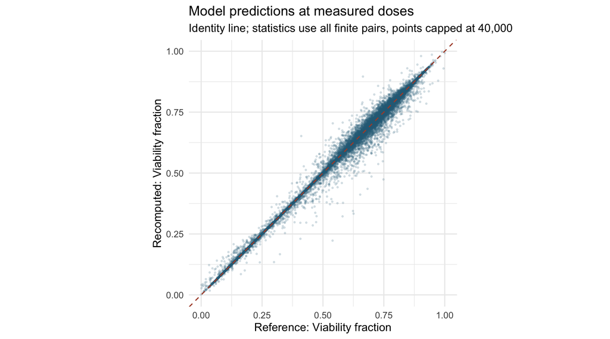

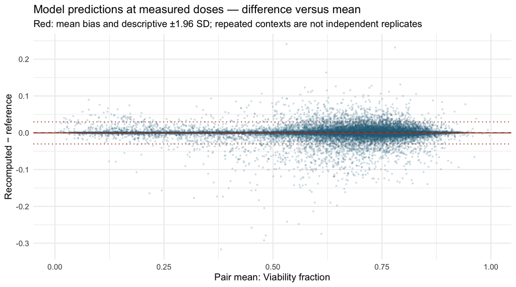

| sampleid | treatment1id | plateid | paired_doses | prediction_MAE | source_RMSE | current_RMSE |
| --- | --- | --- | --- | --- | --- | --- |
| KMM1_JCRB | NCGC00016000-10 | T5612664 | 11 | 0.1690 | 0.3451 | 0.2945 |
| OCIMY5_PLB | NCGC00159356-02 | T5554046 | 11 | 0.1631 | 0.3499 | 0.2885 |
| ARP1_JJKsccF8 | NCGC00249389-01 | T5560454 | 11 | 0.1418 | 0.3008 | 0.2199 |
| MM1S_ATCC | NCGC00249389-01 | T5557276 | 11 | 0.1313 | 0.1795 | 0.1754 |
| KMM1_JCRB | NCGC00166125-01 | T5618060 | 11 | 0.1305 | 0.3720 | 0.3393 |
| OPM2_DSMZ | NCGC00249389-01 | T5562316 | 11 | 0.1305 | 0.2789 | 0.2123 |
| KMS27_JCRB | NCGC00016000-10 | T5617222 | 11 | 0.1278 | 0.3291 | 0.2788 |
| L363_DSMZ | NCGC00162381-03 | T5612680 | 11 | 0.1230 | 0.2632 | 0.2124 |
| MOLP8_DSMZ | NCGC00167488-03 | T5553468 | 11 | 0.1229 | 0.1571 | 0.1326 |
| KMM1_JCRB | NCGC00249389-01 | T5612668 | 11 | 0.1220 | 0.2849 | 0.2490 |

| curves | paired_curves | median_prediction_MAE | median_source_RMSE | median_current_RMSE |
| --- | --- | --- | --- | --- |
| 82216 | 80192 | 0.001 | 0.0435 | 0.0436 |

Errors against training observations describe fit fidelity; they do not establish generalization. Published models are unconstrained LL.4 fits and current fitting responses are clipped to [0,1], so neither curve is assumed correct solely because its in-sample error is smaller.

## Representative curves and discrepant fits

We show fitted values without refitting: published LL.4 parameters and the installed PharmacoGx Hill evaluator. Three curves are selected near the 10th, 50th and 90th R² percentiles, and three by largest absolute log-EC50 discrepancy among in-range pairs. Selection is deterministic and not based on a desired biological conclusion.

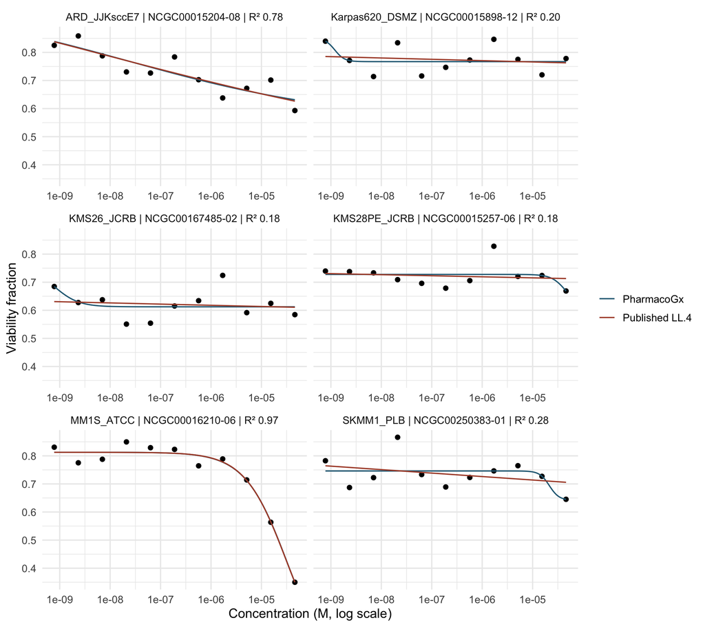

| sampleid | treatment1id | plateid | curve | Rsquare | ac50 | EC50 | delta_log_M |
| --- | --- | --- | --- | --- | --- | --- | --- |
| SKMM1_PLB | NCGC00250383-01 | T5551134 | SKMM1_PLB \| NCGC00250383-01 \| R² 0.28 | 0.2772 | 0 | 0 | 2.3944 |
| ARD_JJKsccE7 | NCGC00015204-08 | T5622792 | ARD_JJKsccE7 \| NCGC00015204-08 \| R² 0.78 | 0.7796 | 0 | 0 | 0.7402 |
| MM1S_ATCC | NCGC00016210-06 | T5557258 | MM1S_ATCC \| NCGC00016210-06 \| R² 0.97 | 0.9746 | 0 | 0 | 0.0231 |
| Karpas620_DSMZ | NCGC00015898-12 | T5617968 | Karpas620_DSMZ \| NCGC00015898-12 \| R² 0.20 | 0.2002 | 0 | 0 | -4.5803 |
| KMS26_JCRB | NCGC00167485-02 | T5556134 | KMS26_JCRB \| NCGC00167485-02 \| R² 0.18 | 0.1767 | 0 | 0 | -4.5281 |
| KMS28PE_JCRB | NCGC00015257-06 | T5553540 | KMS28PE_JCRB \| NCGC00015257-06 \| R² 0.18 | 0.1760 | 0 | 0 | 4.5168 |

## A small response-landscape analysis

A cell-by-compound AAC matrix summarizes sensitivity across the panel. PCA is centered by compound but not variance-scaled, so compounds with more response variation contribute more. The heatmap uses the 25 most variable compounds, selected before any genotype comparison. Neither clustering nor PCA establishes a biomarker.

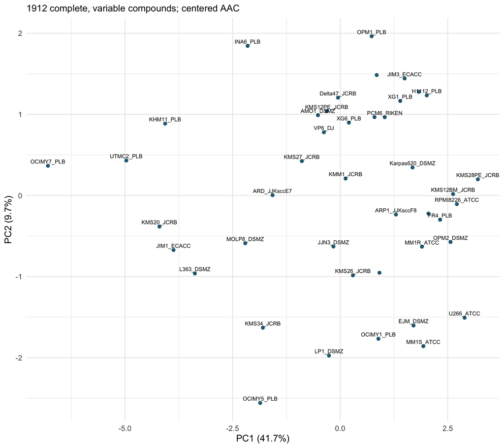

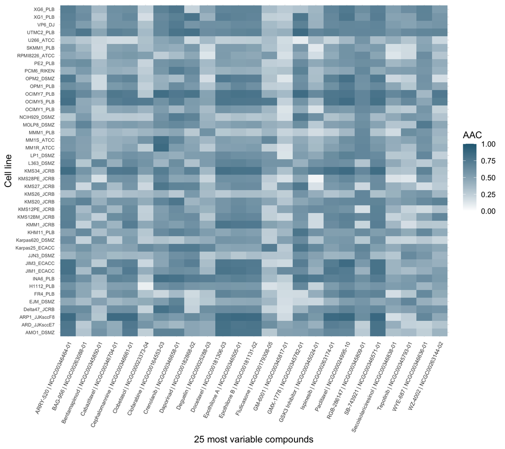

## Exploratory myeloma genotype–response example

The source cell-characteristic table provides TP53 status separately from the predicted-variant matrix. As a prespecified biological example, compare the MDM2 inhibitor **Nutlin-3** across source-reported TP53 wild-type versus altered lines. This is an exploratory check, not validation of a causal biomarker. Ambiguous/missing annotations are excluded and shown; different Nutlin compound identifiers remain separate. A two-sided Wilcoxon test is only run when both groups have at least three lines; BH correction covers the displayed compound tests.

| TP53 | cells |
| --- | --- |
| Source WT | 4 |
| Source altered | 32 |
| Unclassified | 7 |

| treatment1id | treatment_name | TP53 | cells | median_AAC |
| --- | --- | --- | --- | --- |
| NCGC00263124-01 | Nutlin-3 | Source WT | 4 | 0.3201 |
| NCGC00263124-01 | Nutlin-3 | Source altered | 32 | 0.2490 |
| NCGC00263124-01 | Nutlin-3 | Unclassified | 7 | 0.3976 |

| treatment1id | treatment_name | n_WT | n_altered | p | BH |
| --- | --- | --- | --- | --- | --- |
| NCGC00263124-01 | Nutlin-3 | 4 | 32 | 0.0415 | 0.0415 |

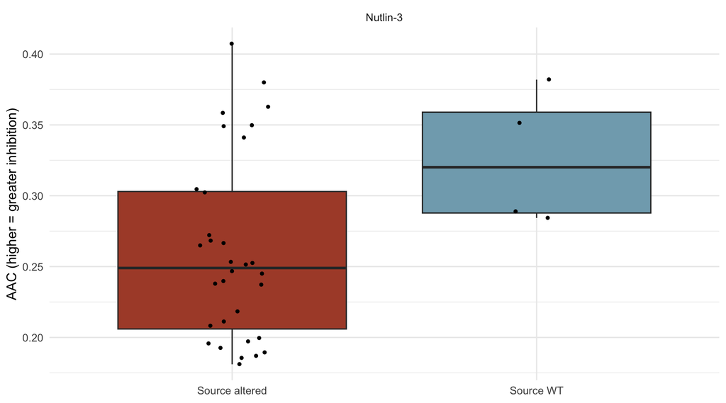

## Fitted concentration convention

Stored IC50 uses the relative half-effect convention (`reference="relative"`): it is not necessarily the concentration at 50% absolute viability. EC50 is the fitted midpoint. Read these values alongside the tested concentration range and curve asymptotes; extrapolated potency can be poorly identified.

## Annotation coverage

Unmatched identifiers remain usable source IDs. Empty AnnotationGx fields mean that mapping method was not run; they do not indicate a negative database result.

| entity | total | annotationdb_mapped |
| --- | --- | --- |
| samples | 43 | 40 |
| treatments | 1912 | 1365 |

annotationdb_cell_line_misses

| sampleid | sample_name | tissueid | Cellosaurus.Accession | In.AnnotationDB | AnnotationGx.Mapped | AnnotationGx.Title |
| --- | --- | --- | --- | --- | --- | --- |
| U266_ATCC | U266_ATCC | haematopoietic_and_lymphoid | NA | FALSE | NA | NA |
| LP1_DSMZ | LP1_DSMZ | haematopoietic_and_lymphoid | NA | FALSE | NA | NA |
| H1112_PLB | H1112_PLB | haematopoietic_and_lymphoid | NA | FALSE | NA | NA |

annotationdb_compound_misses

| treatmentid | treatment_name | alias | development_phase | mechanistic_class | mechanisms_cellular | target_class | gene_symbol_1 | gene_symbol_2 | gene_symbol_3 | gene_symbol_4 | gene_symbol_5 | moa1 | moa2 | moa3 | moa4 | moa5 | binary_pharmacology | general_indication | cas | target_subcat | class | primary_mechanism | additional_mechanisms | mechanisms_cellular_apoptosis | mechanisms_cellular_angiogenesis | mechanisms_cellular_signal_transduction | PubChem.CID | In.AnnotationDB | AnnotationGx.Mapped | … |
| --- | --- | --- | --- | --- | --- | --- | --- | --- | --- | --- | --- | --- | --- | --- | --- | --- | --- | --- | --- | --- | --- | --- | --- | --- | --- | --- | --- | --- | --- | --- |
| NCGC00274062-01 | Zosuquidar | LY-335979 | Phase III | Transporter | NA | ABC transporter | ABCB1 | NA | NA | NA | NA | Multidrug resistance protein 1 Inhibitor | NA | NA | NA | NA | Inhibitor | Oncology | 167465-36-3 | NA | NA | NA | NA | FALSE | FALSE | FALSE | NA | FALSE | NA | … |
| NCGC00249389-01 | LDN-193189 | NA | Preclinical | Cell signaling | Signal Transduction Modulators | Kinase | ACVR1 | BMPR1A | ACVRL1 | NA | NA | ALK2 Inhibitor | Bone morphogenetic protein receptor type-1A Inhibitor | Activin Receptor type-1C Inhibitor | NA | NA | Inhibitor | Oncology | 1062368-62-0 | NA | NA | NA | NA | FALSE | FALSE | TRUE | NA | FALSE | NA | … |
| NCGC00018117-23 | Theophyllamine | NA | Approved | Cell signaling | Signal Transduction Modulators | GPCR signaling | ADORA1 | CHIA | NA | NA | NA | Adenosine Receptor A1 Antagonist | Acidic mammalian chitinase Inhibitor | GABA(A) Receptor Antagonist | NA | NA | Antagonist | Neurological Disorders | 317-34-0 | NA | NA | NA | NA | FALSE | FALSE | TRUE | NA | FALSE | NA | … |
| NCGC00263139-01 | Rolofylline | MK-7418 | Phase III | Cell signaling | Signal Transduction Modulators | GPCR signaling | ADORA1 | NA | NA | NA | NA | Adenosine Receptor A1 Antagonist | NA | NA | NA | NA | Antagonist | Neurological Disorders | 136199-02-5 | NA | NA | NA | NA | FALSE | FALSE | TRUE | NA | FALSE | NA | … |
| NCGC00024976-04 | CGS-21680 | NA | Preclinical | Cell signaling | Signal Transduction Modulators | GPCR signaling | ADORA2A | NA | NA | NA | NA | Adenosine Receptor A2A Agonist | NA | NA | NA | NA | Agonist | Neurological Disorders | 124431-80-7 | NA | NA | NA | NA | FALSE | FALSE | TRUE | NA | FALSE | NA | … |
| NCGC00345800-01 | GS-6201 | CVT-6883 | Phase I | Cell signaling | Signal Transduction Modulators | GPCR signaling | ADORA2B | NA | NA | NA | NA | Adenosine Receptor A2B Antagonist | NA | NA | NA | NA | Antagonist | Neurological Disorders | 752222-83-6 | NA | NA | NA | NA | FALSE | FALSE | TRUE | NA | FALSE | NA | … |
| NCGC00159406-11 | Noradrenaline | Norepinephrine | Approved | Cell signaling | Signal Transduction Modulators | GPCR signaling | ADRA1A | NA | NA | NA | NA | Alpha-1A Adrenergic Receptor Agonist | Beta-Adrenergic Receptor Agonist | NA | NA | NA | Agonist | Neurological Disorders | 51-40-1 | NA | NA | NA | NA | FALSE | FALSE | TRUE | NA | FALSE | NA | … |
| NCGC00015558-06 | Isoprenaline | NA | Approved | Cell signaling | NA | GPCR signaling | ADRB1 | NA | NA | NA | NA | Beta-1 Adrenergic Receptor Agonist | NA | NA | NA | NA | Agonist | Neurological Disorders | 51-30-9 | NA | NA | NA | NA | FALSE | FALSE | FALSE | NA | FALSE | NA | … |
| NCGC00263553-02 | StemRegenin 1 | SR-1 | Preclinical | Transcription regulation | Signal Transduction Modulators | Transcription factor | AHR | NA | NA | NA | NA | Aryl Hydrocarbon Receptor Antagonist | NA | NA | NA | NA | Antagonist | Metabolic Disorders | 1227633-49-9 | NA | NA | NA | NA | FALSE | FALSE | TRUE | NA | FALSE | NA | … |
| NCGC00024631-01 | EBPC | NA | Preclinical | Metabolism | NA | Glucose metabolism | AKR1B1 | NA | NA | NA | NA | Aldose Reductase Inhibitor | NA | NA | NA | NA | Inhibitor | Metabolic Disorders | 4450-98-0 | NA | NA | NA | NA | FALSE | FALSE | FALSE | NA | FALSE | NA | … |
| NCGC00346450-01 | Triciribine phosphate | NSC-280594 | Phase I/II | Cell signaling | NA | Kinase | AKT1 | NA | NA | NA | NA | AKT serine/threonine kinase Inhibitor | NA | NA | NA | NA | Inhibitor | Oncology | 61966-08-3 | NA | NA | NA | NA | FALSE | FALSE | FALSE | NA | FALSE | NA | … |
| NCGC00345822-01 | Akt-I-1 | NA | Preclinical | Cell signaling | NA | Kinase | AKT1 | NA | NA | NA | NA | AKT serine/threonine kinase 1 Inhibitor | NA | NA | NA | NA | Inhibitor | Oncology | 473382-39-7 | NA | NA | NA | NA | FALSE | FALSE | FALSE | NA | FALSE | NA | … |
| NCGC00345823-01 | Akt-I-1,2 | NA | Preclinical | Cell signaling | NA | Kinase | AKT1 | AKT2 | AKT3 | NA | NA | AKT serine/threonine kinase Inhibitor | AKT serine/threonine kinase 2 Inhibitor | AKT serine/threonine kinase 3 Inhibitor | NA | NA | Inhibitor | Oncology | 473382-50-2 | NA | NA | NA | NA | FALSE | FALSE | FALSE | NA | FALSE | NA | … |
| NCGC00345856-01 | AZD-26 | NA | Preclinical | Cell signaling | Signal Transduction Modulators | Kinase | AKT1 | NA | NA | NA | NA | AKT serine/threonine kinase 1 Inhibitor | NA | NA | NA | NA | Inhibitor | Oncology | 1357158-81-6 | NA | NA | NA | NA | FALSE | FALSE | TRUE | NA | FALSE | NA | … |
| NCGC00346621-01 | CCT-128930 | NA | Preclinical | Cell signaling | Signal Transduction Modulators | Kinase | AKT1 | NA | NA | RPS6KB1 | NA | AKT serine/threonine kinase Inhibitor | Rho-associated protein kinase Inhibitor | cAMP-Dependent Protein Kinase A Inhibitor | Ribosomal Protein S6 Kinase beta Inhibitor | NA | Inhibitor | Oncology | 885499-61-6 | NA | NA | NA | NA | FALSE | FALSE | TRUE | NA | FALSE | NA | … |

## Response distributions and missing references

A four-parameter Hill model requires adequate concentration support; three distinct concentrations alone cannot independently identify all four parameters. `four_parameter_dose_support` flags this limitation; it is not a guarantee of fit quality.

Measured viability and fitted response summaries answer different questions. Interpret concentration units, tested ranges and missing references before comparing compounds.

| observations | missing_response | min_response | max_response |
| --- | --- | --- | --- |
| 904376 | 0 | 0 | 1 |

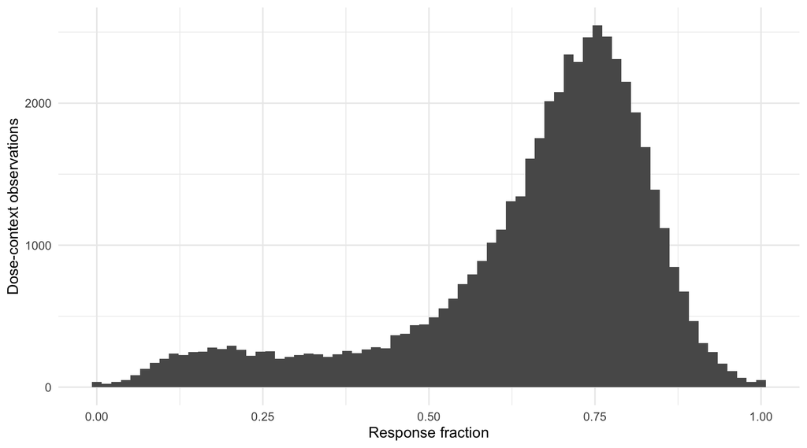

| fit_status | N |
| --- | --- |
| ok | 82216 |

| n_doses | N |
| --- | --- |
| 11 | 82216 |

| four_parameter_dose_support | N |
| --- | --- |
| TRUE | 82216 |

## Molecular identifiers

Gene-level assays use the configured GENCODE release. The mutation layer records predicted variant information; missing values are not assumed to be wild-type.

| assay | features | samples | duplicates | non_ensembl |
| --- | --- | --- | --- | --- |
| mutation.exome | 6178 | 42 | 0 | 0 |

| exclusion_reason | N | assay |
| --- | --- | --- |
| no_unique_current_Ensembl_match | 852 | mutation.exome_feature_mapping.tsv |
|  | 6178 | mutation.exome_feature_mapping.tsv |

## Reported fit quality and the stored curve

For these fitted profiles, `Rsquare` is calculated before the returned asymptotes are truncated to [0,1]. It uses `1 - var(residual)/var(response)`, which also removes a constant residual bias. Consequently, optimizer-reported R² need not describe the returned curve used for downstream metrics. Existing stored fit parameters and reported R² are preserved.

The diagnostics evaluate the stored curve at its modeling concentrations and report both the variance-based statistic and the bias-sensitive `1 - SSE/SST`. Constant-response curves have undefined R². Negative values indicate poor fit and are retained. These are in-sample diagnostics, not tests of predictive performance or potency identifiability.

| assay | fit_status | asymptote_at_boundary | contexts | finite_reported | finite_returned | reported_returned_differ | max_absolute_difference | median_reported | median_returned_variance | reported_below_0_5 | returned_variance_below_0_5 | returned_SSE_below_0_5 |
| --- | --- | --- | --- | --- | --- | --- | --- | --- | --- | --- | --- | --- |
| monotherapy | ok | TRUE | 24604 | 24604 | 24604 | 2615 | 0.3059 | 0.8278 | 0.8248 | 4586 | 4803 | 4992 |
| monotherapy | ok | FALSE | 57612 | 57612 | 57612 | 0 | 0.0000 | 0.7232 | 0.7232 | 18192 | 18192 | 18192 |

| sampleid | tech_rep | plateid | treatment1id | Hill_slope | E0 | E_inf | EC50 | reported_Rsquare | stored_n_doses | fit_status | model_points | input_n_doses | finite_predictions | response_variance | residual_variance | SSE | mean_bias_observed_minus_prediction | returned_variance_Rsquare | returned_SSE_Rsquare | assay | asymptote_at_boundary | difference_reported_minus_returned |
| --- | --- | --- | --- | --- | --- | --- | --- | --- | --- | --- | --- | --- | --- | --- | --- | --- | --- | --- | --- | --- | --- | --- |
| XG1_PLB | T5616524 | T5616524 | NCGC00166294-02 | 4.5000 | 0.9139 | 1 | 0e+00 | 0.6249 | 11 | ok | 11 | 11 | 11 | 0.0010 | 0.0006 | 0.0068 | 0.0052 | 0.3190 | 0.2879 | monotherapy | TRUE | 0.3059 |
| KMS12PE_JCRB | T5612688 | T5612688 | NCGC00090691-03 | 3.9165 | 0.8720 | 1 | 1e-04 | 0.6358 | 11 | ok | 11 | 11 | 11 | 0.0023 | 0.0014 | 0.0146 | 0.0073 | 0.3994 | 0.3746 | monotherapy | TRUE | 0.2364 |
| KMS28PE_JCRB | T5555990 | T5555990 | NCGC00181771-01 | 0.4860 | 0.8056 | 1 | 1e-04 | 0.8696 | 11 | ok | 11 | 11 | 11 | 0.0031 | 0.0011 | 0.0160 | 0.0211 | 0.6440 | 0.4864 | monotherapy | TRUE | 0.2256 |
| NCIH929_DSMZ | T5614442 | T5614442 | NCGC00346680-01 | 0.7661 | 0.8531 | 1 | 1e-04 | 0.6739 | 11 | ok | 11 | 11 | 11 | 0.0032 | 0.0018 | 0.0203 | 0.0157 | 0.4488 | 0.3635 | monotherapy | TRUE | 0.2251 |
| PE2_PLB | T5612884 | T5612884 | NCGC00182055-02 | 0.5688 | 0.8151 | 1 | 1e-04 | 0.8152 | 11 | ok | 11 | 11 | 11 | 0.0033 | 0.0013 | 0.0173 | 0.0191 | 0.5923 | 0.4691 | monotherapy | TRUE | 0.2229 |
| H1112_PLB | T5617456 | T5617456 | NCGC00345830-01 | 1.1889 | 0.8385 | 1 | 1e-04 | 0.6972 | 11 | ok | 11 | 11 | 11 | 0.0033 | 0.0017 | 0.0189 | 0.0122 | 0.4801 | 0.4308 | monotherapy | TRUE | 0.2171 |
| H1112_PLB | T5617444 | T5617444 | NCGC00016268-09 | 1.1616 | 0.7967 | 1 | 0e+00 | 0.8398 | 11 | ok | 11 | 11 | 11 | 0.0044 | 0.0016 | 0.0186 | 0.0143 | 0.6287 | 0.5778 | monotherapy | TRUE | 0.2110 |
| OPM2_DSMZ | T5562292 | T5562292 | NCGC00094872-08 | 4.5000 | 0.8182 | 1 | 1e-04 | 0.7639 | 11 | ok | 11 | 11 | 11 | 0.0007 | 0.0003 | 0.0032 | 0.0036 | 0.5541 | 0.5327 | monotherapy | TRUE | 0.2098 |
| Karpas25_ECACC | T5613846 | T5613846 | NCGC00346701-01 | 0.7834 | 0.8273 | 1 | 1e-04 | 0.7088 | 11 | ok | 11 | 11 | 11 | 0.0032 | 0.0016 | 0.0182 | 0.0146 | 0.5017 | 0.4278 | monotherapy | TRUE | 0.2071 |
| NCIH929_DSMZ | T5613350 | T5613350 | NCGC00167429-05 | 4.5000 | 0.8549 | 1 | 1e-04 | 0.6119 | 11 | ok | 11 | 11 | 11 | 0.0022 | 0.0013 | 0.0138 | 0.0066 | 0.4060 | 0.3850 | monotherapy | TRUE | 0.2060 |

All other tables and plots labeled `Rsquare` or R² retain the original optimizer-reported statistic unless explicitly labeled as returned-curve diagnostics. The full diagnostic table preserves identifiers, assay, dose counts and both quality definitions for review.